# Challenge: Discrimination in the EU

Mafalda González, David Pereiro, Irene Bosque y Pablo Aísa

2025-03-14

# Introduction

```r
library(tidyverse)
library(readxl)
library(haven)
library(patchwork)
library(scales)
library(countries)
library(showtext)
library(mice)
library(DataExplorer)
library(ggrepel)
```

```r
library(plotly)
library(rworldmap)
library(janitor)
library(car)
library(lme4)
library(ggplot2)
library(RColorBrewer)
library(caret)
library(rpart)
library(rpart.plot)
```

# Data cleaning

To analyse the effect of different country-level characteristics we have obtained data from the [World Bank](https://www.worldbank.org/ext/en/home), [ILGA Europe (Rainbow Map)](https://rainbowmap.ilga-europe.org/) and from the [Trans Rights Indicator Project by Harvard University](https://dataverse.harvard.edu/dataset.xhtml?persistentId=doi:10.7910/DVN/FXXLTS).

## Country-level variables

```r
# Religiosity-----------------------------------------------
religiosity <- read_dta("data/replication_data.dta")

religiosity <- religiosity |>
  group_by(country_name) |>
  slice_max(year) |>
  ungroup()

religiosity <- religiosity |>
  select(religiosity_percent, country_name)

religiosity <- religiosity |>
  mutate(country = country_name(country_name, to = "simple",
                                verbose = TRUE),
         country_iso = countrycode::countrycode(country, origin = "country.name",
                                                destination = "iso2c")) |>
  select(country_iso, religiosity_percent)
```

```
##
## In total 173 unique country names were provided
## 172/173 have been matched with EXACT matching
## 1/173 have been matched with FUZZY matching
```

```r
# Economic indicators---------------------------------------
economic_indicators <- read_xlsx("data/country_data.xlsx")

economic_indicators <- economic_indicators |>
  drop_na(`Series Code`)

economic_indicators <- economic_indicators %>%
  mutate(across(everything(), ~ str_remove_all(.x, "^\\.\\.$"))) %>%
  mutate(across(everything(), ~ if_else(.x == "", NA, .x)))

economic_indicators <- economic_indicators %>%
  mutate(latest_value = coalesce(`2023 [YR2023]`,
                                 `2022 [YR2022]`,
                                 `2021 [YR2021]`,
                                 `2020 [YR2020]`)) |>
  mutate(latest_value = as.numeric(latest_value))

economic_indicators <- economic_indicators |>
  select(`Series Name`, `Country Name`, latest_value)

economic_indicators <- economic_indicators |>
  pivot_wider(names_from = `Series Name`, values_from = latest_value )

economic_indicators <- economic_indicators |>
  rename("country" = "Country Name",
         "gini" = "Gini index",
         "gdp_pc" = "GDP per capita (constant 2015 US$)")

economic_indicators <- economic_indicators |>
  mutate(country = country_name(country, to = "simple",
                                verbose = TRUE),
         country_iso = countrycode::countrycode(country,
                                                origin = "country.name",
                                                destination = "iso2c")) |>
  select(country_iso, gini, gdp_pc)
```

```
##
## In total 58 unique country names were provided
## 57/58 have been matched with EXACT matching
## 1/58 have been matched with FUZZY matching
```

```r
economic_indicators <- economic_indicators |>
  add_row(country_iso = "MT", gini = 31.4, gdp_pc = 33000.6)
```

```r
# Trans laws------------------------------------------------

trans <-  read_csv("data/trans.csv")
```

```
## ──────────────────────────────────────────────────────── Delimiter: "," chr
## (17): ...1, ...2, Legal gender recognition...3, Legal gender recognition...
```

```r
trans <- trans |>
  row_to_names(row_number = 1)
trans <- trans |>
  clean_names() |>
  select(2, 8) |>
  drop_na(na_2) |>
  rename("country" = "na_2")

trans <- trans |>
  mutate(country = country_name(country, to = "simple",
                                verbose = TRUE),
         country_iso = countrycode::countrycode(country, origin = "country.name",
                                                destination = "iso2c")) |>
  select(country_iso, self_determination)
```

```
##
## In total 49 unique country names were provided
## 49/49 have been matched with EXACT matching
## 0/49 have been matched with FUZZY matching
```

```r
# Rainbow score---------------------------------------------
rainbow <- read_csv("data/rainbow.csv")
```

```
## ──────────────────────────────────────────────────────── Delimiter: "," chr
## (77): ...1, ...2, Equality & non-discrimination...4, Equality & non-disc... num
## (1): RANKING
```

```r
rainbow <- rainbow |>
  row_to_names(row_number = 1) |>
  clean_names() |>
  select(2, 3) |>
  drop_na(na_2) |>
  rename("country" = "na_2",
         "rain_ind" = "na_3") |>
  mutate(rain_ind = as.numeric(rain_ind) / 100)
rainbow <- rainbow |>
  mutate(country = country_name(country, to = "simple",
                                verbose = TRUE),
         country_iso = countrycode::countrycode(country, origin = "country.name",
                                                destination = "iso2c")) |>
  select(country_iso, rain_ind)
```

```
##
## In total 49 unique country names were provided
## 49/49 have been matched with EXACT matching
## 0/49 have been matched with FUZZY matching
```

## Individual level variables from the survey

```r
survey <- read_dta("data/ZA7575.dta")

survey <- survey |>
  select(caseid, serialid, isocntry, d10, d11,
         d1, sd3, d7, sd1_4, sd1_7, sd1_8, d70,
         d63, qc19, d15a, d60, qc13_11, qc6_10, qc17_4)

# Recode dependent variable
filtered_survey <- survey |>
  mutate(trans_doc = case_when(
    qc19==1 ~ 1,
    qc19==2 ~ 0,
    qc19==3 ~ NA))

# Recode gender
filtered_survey <- filtered_survey |>
  mutate(female = case_when(
    d10 == 1 ~ 0,
    d10 == 2 ~ 1,
    TRUE ~ NA),
    female = factor(female))

# Recode age
filtered_survey <- filtered_survey |>
  mutate(age = if_else(d11 == 99 , NA, d11))

# Current occupation
filtered_survey <- filtered_survey |>
  mutate(occupation = case_when(
    d15a %in% c(1, 3) ~ "Unemployed",
    d15a == 2 ~ "Student",
    d15a == 4 ~ "Retired",
    d15a <= 9 ~ "Self employed",
    d15a <=  18 ~ "Employed" ,
    TRUE ~ NA),
    occupation = factor(occupation))

# Recode religion
filtered_survey <- filtered_survey |>
  mutate(religion = case_when(
    sd3 %in% c(1, 3, 4) ~ "Christians",
    sd3 == 2 ~ "Orthodox Chrsitian",
    sd3 %in% c(6, 7, 8) ~ "Muslims",
    sd3 %in% c(5, 9, 10, 11, 14) ~ "Other religions",
    sd3 %in% c(12, 13) ~ "Not religious",
    TRUE ~ NA),
    religion = factor(religion))

# Marital status
filtered_survey <- filtered_survey |>
  mutate(marital_status = case_when(
    d7 <= 4 ~ "Married",
    d7 <= 10 ~ "Single",
    d7 <= 12 ~ "Divorced",
    d7 <=  14 ~ "Widowed",
    d7 == 15 ~ "Other",
    TRUE ~ NA),
    marital_status = factor(marital_status))

# Personal satisfaction
filtered_survey <- filtered_survey |>
  mutate(personal_satis = if_else(d70 == 5, NA, d70),
         personal_satis = case_when(
           personal_satis <= 2 ~ "Satisfied",
           personal_satis > 2 ~ "Not satisfied"))

# Ideology
filtered_survey <- filtered_survey |>
  mutate(ideology = if_else(d1 > 10, NA, d1))

# Contact LGBTQ+
filtered_survey <- filtered_survey |>
  mutate(contact_lgbti = case_when(
    sd1_4 == 1 | sd1_7 == 1 | sd1_8 == 1 ~ "Contact", # There is contact
    sd1_4 == 2 | sd1_7 == 2 | sd1_8 == 2 ~ "No contact", # There is not contact
    TRUE ~ NA),
  contact_lgbti = factor(contact_lgbti))

# Self-perception of the social class
filtered_survey <- filtered_survey |>
  mutate(social_class = case_when(
    d63 %in% c(1, 2) ~ "Working class",
    d63 == 3 ~ "Middle class",
    d63 %in% c(4, 5) ~ "High class",
    TRUE ~ NA))

# Country names: DE-E and DE-W were problems
filtered_survey <- filtered_survey |>
  mutate(country = country_name(isocntry, to = "simple",
                                verbose = TRUE, poor_matches = TRUE),
         isocntry = countrycode::countrycode(
           country, origin = "country.name", destination = "iso2c"))
```

```
##
## In total 29 unique country names were provided
## 27/29 have been matched with EXACT matching
## 2/29 have been matched with FUZZY matching, out of which:
## 2/2 are a POOR match (likely wrongly identified)
##
##
## Multiple arguments have been matched to the same country name:
##   - DE-E : Germany
##   - DE-W : Germany
##
## The matching for the following countries is likely inaccurate:
## (Set - poor_matches - to FALSE to return NAs and - na_fill - to replace the NAs with the original name in - x)
##  - DE-E : Germany
##  - DE-W : Germany
```

```r
individual_data <- filtered_survey |>
  select(caseid, serialid, isocntry, trans_doc, female, age, religion,
         marital_status, personal_satis, ideology,
         contact_lgbti, social_class, occupation)
```

## Structural Cleaning and Final Merge

Before merging all datasets and proceeding with the analysis, we conducted an initial assessment of their characteristics to verify data consistency and ensure a reliable analytical process.

```r
str(individual_data)
```

```
## tibble [27,438 × 13] (S3: tbl_df/tbl/data.frame)
##  $ caseid        : num [1:27438] 47 53 55 56 62 67 69 70 71 81 ...
##   ..- attr(*, "label")= chr "KANTAR CASE ID"
##   ..- attr(*, "format.stata")= chr "%12.0g"
##  $ serialid      : num [1:27438] 1 2 3 4 5 6 7 8 9 10 ...
##   ..- attr(*, "label")= chr "SERIAL CASE ID (PROVIDED BY KANTAR)"
##   ..- attr(*, "format.stata")= chr "%8.0g"
##  $ isocntry      : chr [1:27438] "BE" "BE" "BE" "BE" ...
##  $ trans_doc     : num [1:27438] 1 1 1 1 1 1 1 0 1 1 ...
##  $ female        : Factor w/ 2 levels "0","1": 1 2 2 1 2 2 1 1 2 2 ...
##  $ age           : dbl+lbl [1:27438] 51, 62, 38, 29, 63, 41, 48, 88, 44, 45, 54, 34, 23, ...
##    ..@ label       : chr "AGE EXACT"
##    ..@ format.stata: chr "%8.0g"
##    ..@ labels      : Named num [1:2] 15 98
##    .. ..- attr(*, "names")= chr [1:2] "15 years" "98 years"
##  $ religion      : Factor w/ 5 levels "Christians","Muslims",..: 1 1 3 3 1 3 3 1 1 1 ...
##  $ marital_status: Factor w/ 5 levels "Divorced","Married",..: 1 2 2 2 2 2 2 1 2 2 ...
##  $ personal_satis: chr [1:27438] "Satisfied" "Satisfied" "Satisfied" "Satisfied" ...
##  $ ideology      : dbl+lbl [1:27438]  7,  8,  4, 10,  8,  7,  3,  9,  3,  8,  9,  1,  1, ...
##    ..@ label       : chr "LEFT-RIGHT PLACEMENT"
##    ..@ format.stata: chr "%8.0g"
##    ..@ labels      : Named num [1:12] 1 2 3 4 5 6 7 8 9 10 ...
##    .. ..- attr(*, "names")= chr [1:12] "Box 1 - left" "Box 2" "Box 3" "Box 4" ...
##  $ contact_lgbti : Factor w/ 2 levels "Contact","No contact": 2 2 1 1 2 2 2 2 1 1 ...
##  $ social_class  : chr [1:27438] "Working class" "Middle class" "Working class" "High class" ...
##  $ occupation    : Factor w/ 5 levels "Employed","Retired",..: 1 5 1 1 5 1 1 2 5 1 ...
```

```r
str(religiosity)
```

```
## tibble [173 × 2] (S3: tbl_df/tbl/data.frame)
##  $ country_iso        : chr [1:173] "AF" "AL" "DZ" "AO" ...
##  $ religiosity_percent: num [1:173] 1 1 0.982 0.948 0.879 ...
##   ..- attr(*, "label")= chr "Religiosity (%)"
##   ..- attr(*, "format.stata")= chr "%10.0g"
```

```r
str(economic_indicators)
```

```
## tibble [59 × 3] (S3: tbl_df/tbl/data.frame)
##  $ country_iso: chr [1:59] "AL" "AD" "AM" "AT" ...
##  $ gini       : num [1:59] 29.4 NA 27.9 30.7 NA 24.4 26.6 NA 39 NA ...
##  $ gdp_pc     : num [1:59] 5420 40227 5151 46339 5651 ...
```

```r
str(trans)
```

```
## tibble [49 × 2] (S3: tbl_df/tbl/data.frame)
##  $ country_iso       : chr [1:49] "AL" "AD" "AM" "AT" ...
##  $ self_determination: chr [1:49] "0" "0" "0" "0" ...
```

```r
str(rainbow)
```

[output not shown]

We observe some inconsistencies in two fo the data sets: individual_data and religiosity. The problem with the variables in these data sets is that they contain attributes, some are labeled doubles (dbl+lbl), some are not proper factors, etc. This will make working with the data, imputing it, making models as well as making predictions much harder. Hence, it is highly important to clean the data set structurally before continuing.

We first proceed with the individual_data data set:

```r
individual_data <- individual_data %>%
  mutate(

    # labelled numerics => plain numeric
    across(where(~ inherits(., "haven_labelled")), ~ as.numeric(.)),

    # character variables => factors
    isocntry = as.factor(isocntry),
    personal_satis = as.factor(personal_satis),
    social_class = as.factor(social_class),

    # factor variables => proper factors
    trans_doc = factor(trans_doc),
    female = factor(female),
    contact_lgbti = factor(contact_lgbti),
    religion = factor(religion),
    marital_status = factor(marital_status),
    occupation = factor(occupation),

    # dbl+lbl => plain numeric
    ideology = as.numeric(ideology),
    age = as.numeric(age),

    # numeric variables => plain numeric
    caseid = as.numeric(caseid),
    serialid = as.numeric(serialid),
    ) %>%

  # attributes
  mutate(across(everything(), ~ {
    attr(., "label") <- NULL
    attr(., "format.stata") <- NULL
    attr(., "labels") <- NULL
    return(.)
  }))

str(individual_data)
```

```
## tibble [27,438 × 13] (S3: tbl_df/tbl/data.frame)
##  $ caseid        : num [1:27438] 47 53 55 56 62 67 69 70 71 81 ...
##  $ serialid      : num [1:27438] 1 2 3 4 5 6 7 8 9 10 ...
##  $ isocntry      : Factor w/ 28 levels "AT","BE","BG",..: 2 2 2 2 2 2 2 2 2 2 ...
##  $ trans_doc     : Factor w/ 2 levels "0","1": 2 2 2 2 2 2 2 1 2 2 ...
##  $ female        : Factor w/ 2 levels "0","1": 1 2 2 1 2 2 1 1 2 2 ...
##  $ age           : num [1:27438] 51 62 38 29 63 41 48 88 44 45 ...
##  $ religion      : Factor w/ 5 levels "Christians","Muslims",..: 1 1 3 3 1 3 3 1 1 1 ...
##  $ marital_status: Factor w/ 5 levels "Divorced","Married",..: 1 2 2 2 2 2 2 1 2 2 ...
##  $ personal_satis: Factor w/ 2 levels "Not satisfied",..: 2 2 2 2 2 2 2 2 2 2 ...
##  $ ideology      : num [1:27438] 7 8 4 10 8 7 3 9 3 8 ...
##  $ contact_lgbti : Factor w/ 2 levels "Contact","No contact": 2 2 1 1 2 2 2 2 1 1 ...
##  $ social_class  : Factor w/ 3 levels "High class","Middle class",..: 3 2 3 1 1 2 2 2 2 1 ...
##  $ occupation    : Factor w/ 5 levels "Employed","Retired",..: 1 5 1 1 5 1 1 2 5 1 ...
```

And then we repeat the process for the religiosity data set:

```r
religiosity <- religiosity |>
  mutate(across(everything(), ~{
    attr(.,"label") <- NULL
    attr(., "format.stata") <- NULL
    return(.)
  }))
```

Now, we can finally merge all the datasets using left_join:

```r
# Final merge
data_descriptive <- individual_data |>
  left_join(rainbow, by = c("isocntry" = "country_iso")) |>
  left_join(trans, by = c("isocntry" = "country_iso")) |>
  left_join(economic_indicators, by = c("isocntry" = "country_iso")) |>
  left_join(religiosity, by = c("isocntry" = "country_iso"))
```

## Other interesting variables from the survey

```r
other_variables <- filtered_survey |>
  select(isocntry, qc13_11, qc6_10, qc17_4)

# How comfortable you would feel if one of your children was in love with a trans person
other_variables <- other_variables |>
  mutate(child_love = if_else(qc13_11 > 10, NA, qc13_11))

# Transgender person in a high political position
other_variables <- other_variables |>
  mutate(trans_pol = if_else(qc6_10 > 10, NA, qc6_10))

# Information in schools about being transgender
other_variables <- other_variables |>
  mutate(trans_school = case_when(
    qc17_4 == 1 ~ "Totally agree",
    qc17_4 == 2 ~ "Tend to agree",
    qc17_4 == 3 ~ "Tend to disagree",
    qc17_4 == 4 ~ "Totally disagree",
    TRUE ~ NA),
    trans_school = factor(trans_school))

other_variables <- other_variables |>
  mutate(country = country_name(isocntry, to = "simple",
                                verbose = TRUE, poor_matches = TRUE),
         isocntry = countrycode::countrycode(
           country, origin = "country.name", destination = "iso2c"))
```

```
##
## In total 28 unique country names were provided
## 28/28 have been matched with EXACT matching
## 0/28 have been matched with FUZZY matching
```

```r
other_variables <- other_variables |>
  select(child_love, trans_pol, trans_school, isocntry)
```

# Descriptive analysis

## Individual descriptive analysis

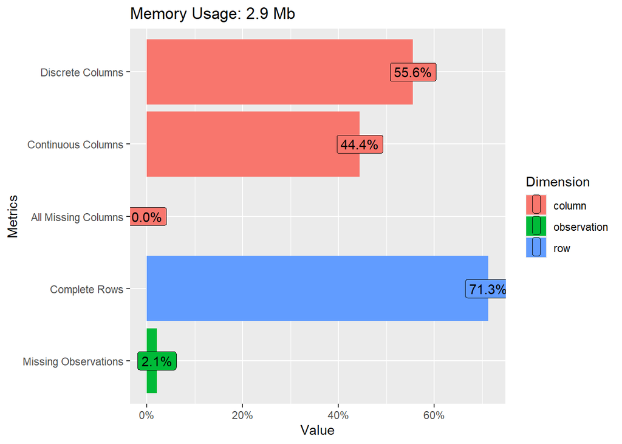

```r
plot_intro(data_descriptive)
```

Before diving into an in-depth analysis of the dataset, we first examine its key characteristics using this plot_intro. We observe that 55.6% of the dataset consists of discrete variables, while 44.4% are continuous. Additionally, 71.3% of the rows are complete, meaning they contain no missing values in any variable. The total percentage of missing values is minimal, accounting for just 2.1%.

```r
str(data_descriptive)
```

```
## tibble [27,438 × 18] (S3: tbl_df/tbl/data.frame)
##  $ caseid             : num [1:27438] 47 53 55 56 62 67 69 70 71 81 ...
##  $ serialid           : num [1:27438] 1 2 3 4 5 6 7 8 9 10 ...
##  $ isocntry           : chr [1:27438] "BE" "BE" "BE" "BE" ...
##  $ trans_doc          : Factor w/ 2 levels "0","1": 2 2 2 2 2 2 2 1 2 2 ...
##  $ female             : Factor w/ 2 levels "0","1": 1 2 2 1 2 2 1 1 2 2 ...
##  $ age                : num [1:27438] 51 62 38 29 63 41 48 88 44 45 ...
##  $ religion           : Factor w/ 5 levels "Christians","Muslims",..: 1 1 3 3 1 3 3 1 1 1 ...
##  $ marital_status     : Factor w/ 5 levels "Divorced","Married",..: 1 2 2 2 2 2 2 1 2 2 ...
##  $ personal_satis     : Factor w/ 2 levels "Not satisfied",..: 2 2 2 2 2 2 2 2 2 2 ...
##  $ ideology           : num [1:27438] 7 8 4 10 8 7 3 9 3 8 ...
##  $ contact_lgbti      : Factor w/ 2 levels "Contact","No contact": 2 2 1 1 2 2 2 2 1 1 ...
##  $ social_class       : Factor w/ 3 levels "High class","Middle class",..: 3 2 3 1 1 2 2 2 2 1 ...
##  $ occupation         : Factor w/ 5 levels "Employed","Retired",..: 1 5 1 1 5 1 1 2 5 1 ...
##  $ rain_ind           : num [1:27438] 78.5 78.5 78.5 78.5 78.5 ...
##  $ self_determination : chr [1:27438] "1" "1" "1" "1" ...
##  $ gini               : num [1:27438] 26.6 26.6 26.6 26.6 26.6 26.6 26.6 26.6 26.6 26.6 ...
##  $ gdp_pc             : num [1:27438] 44731 44731 44731 44731 44731 ...
##  $ religiosity_percent: num [1:27438] 0.689 0.689 0.689 0.689 0.689 ...
```

```r
summary(data_descriptive)
```

```
##      caseid           serialid       isocntry         trans_doc    female
##  Min.   :      1   Min.   :    1   Length:27438       0   : 9695   0:12492
##  1st Qu.:    731   1st Qu.: 6860   Class :character   1   :14463   1:14946
##  Median :   1436   Median :13720   Mode  :character   NA's: 3280
##  Mean   : 202789   Mean   :13720
##  3rd Qu.:   2322   3rd Qu.:20579
##  Max.   :9999999   Max.   :27438
##
##       age                      religion      marital_status
##  Min.   :15.00   Christians        :15412   Divorced: 2243
##  1st Qu.:37.00   Muslims           :  392   Married :14673
##  Median :53.00   Not religious     : 5803   Other   :  107
##  Mean   :51.56   Orthodox Chrsitian: 4016   Single  : 7635
##  3rd Qu.:66.00   Other religions   : 1332   Widowed : 2712
##  Max.   :98.00   NA's              :  483   NA's    :   68
##
##        personal_satis     ideology         contact_lgbti
##  Not satisfied: 4738   Min.   : 1.000   Contact   :11422
##  Satisfied    :22598   1st Qu.: 4.000   No contact:15522
##  NA's         :  102   Median : 5.000   NA's      :  494
##                        Mean   : 5.309
##                        3rd Qu.: 7.000
##                        Max.   :10.000
##                        NA's   :4689
##         social_class           occupation       rain_ind     self_determination
##  High class   : 2046   Employed     :12330   Min.   :17.50   Length:27438
##  Middle class :13068   Retired      : 8791   1st Qu.:29.51   Class :character
##  Working class:11303   Self employed: 1979   Median :50.07   Mode  :character
##  NA's         : 1021   Student      : 1676   Mean   :50.08
##                        Unemployed   : 2662   3rd Qu.:67.14
##                                              Max.   :87.84
##
##       gini           gdp_pc       religiosity_percent
##  Min.   :24.10   Min.   :  9820   Min.   :0.2149
##  1st Qu.:28.30   1st Qu.: 18686   1st Qu.:0.6886
##  Median :31.30   Median : 28570   Median :0.8116
##  Mean   :30.82   Mean   : 34549   Mean   :0.7800
##  3rd Qu.:33.90   3rd Qu.: 45589   3rd Qu.:0.9194
##  Max.   :39.00   Max.   :106343   Max.   :1.0000
##
```

The dataset includes both individual-level variables, which capture personal characteristics and opinions, and country-level contextual variables, which help explain cross-country differences in support for transgender rights.

#### **Individual-Level Variables:**

These variables reflect personal attributes, experiences, and attitudes:

- **serialid**: Unique identifier for each participant.
- **isocntry**: Categorical variable distinguishing respondents by country (28 EU member states).
- **trans_doc**: The key variable of this study, measuring attitudes toward the right of transgender individuals to officially change their name and gender. It is binary, with values of 0 (opposition) and 1 (support). In this dataset, 59.9% of participants expressed support.
- **female**: 54.5% of the sample are women (14,946), while 45.5% are men (12,492).
- **age**: Ranges from 15 to 98 years, with a median age of 53. The youngest 25% of respondents are aged 37 or younger, while the oldest 25% are 66 or older. This indicates a relatively older sample, which is relevant for analyzing attitudes, as previous studies have highlighted generational differences in the acceptance of LGBTI rights.
- **religion**: captures respondents’ religious affiliations, showing that a majority identify as Christian, with a smaller proportion reporting no religious affiliation.
- **marital_status**: reflects participants’ relationship status, which may provide insight into how family experiences shape attitudes toward the transgender community.
- **personal_satis**: Categorical variable representing personal life satisfaction, which could be linked to more open or restrictive attitudes.
- **ideology**: A key political scale for analyzing ideological influence. Measured on a 1 to 10 scale, with a median of 5 and a mean of 5.3, suggesting a distribution centered around moderate positions.
- **contact_lgbti**: assesses prior exposure to LGBTI individuals, an important factor in reducing prejudice, with a division between those who have had contact and those who have not.
- **social_class**: Self-perceived social class, indicating the respondent’s socioeconomic context.
- **occupation**: Employment status, allowing us to explore the influence of workplace environments.

#### **Country-Level Contextual Variables:**

In addition to individual-level factors, we incorporate aggregated national indicators to better understand how structural and policy differences influence support for transgender rights.

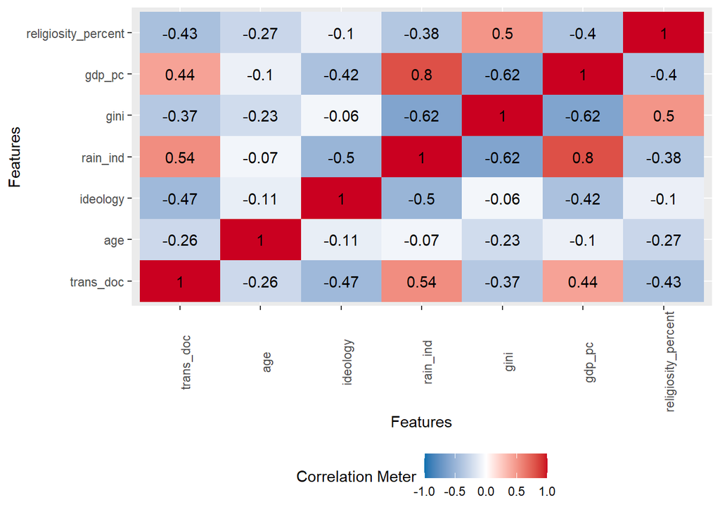

```r
corr_data <- data_descriptive |>
  select(trans_doc, age, ideology, rain_ind, gini, gdp_pc, religiosity_percent) |>
  mutate(trans_doc = as.numeric(trans_doc))

corr_matrix <- cor(corr_data, use = "complete.obs")

plot_correlation(corr_matrix)
```

This correlation matrix highlights that support for transgender rights is significantly shaped by economic, cultural, and policy-related factors. Higher economic development, lower inequality, and strong LGBTI legal protections are associated with greater acceptance, while religiosity, conservatism, and age tend to correlate with lower support.

## Distribution of the individual variables

First of all, we proceed to analyze the distribution of the individual variables in our dataset:

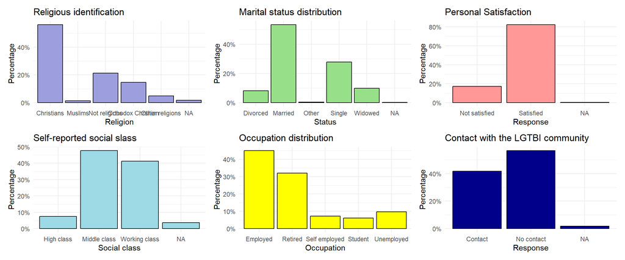

```r
# Religion
g1 <- ggplot(data_descriptive, aes(x = religion)) +
  geom_bar(aes(y = ..prop.., group = 1), fill = "#9C9EDE", color = "black") +
  scale_y_continuous(labels = percent_format()) +
  labs(title = "Religious identification", x = "Religion", y = "Percentage") +
  theme(
    axis.text.x = element_text(angle = 45, hjust = 1),
    axis.title = element_text(size = 12, face = "bold")) +
  theme_minimal()

# Marital status
g2 <- ggplot(data_descriptive, aes(x = marital_status)) +
  geom_bar(aes(y = ..prop.., group = 1), fill = "#98DF8A", color = "black") +
  scale_y_continuous(labels = percent_format()) +
  labs(title = "Marital status distribution", x = "Status", y = "Percentage") +
  theme(
    axis.text.x = element_text(angle = 45, hjust = 1),
    axis.title = element_text(size = 12, face = "bold")) +
  theme_minimal()

# Personal satisfaction
g3 <- ggplot(data_descriptive, aes(x = personal_satis)) +
  geom_bar(aes(y = ..prop.., group = 1), fill = "#FF9896", color = "black") +
  scale_y_continuous(labels = percent_format()) +
  labs(title = "Personal Satisfaction",
       x = "Response", y = "Percentage") +
  theme(
    axis.text.x = element_text(angle = 45, hjust = 1),
    axis.title = element_text(size = 12, face = "bold")) +
  theme_minimal()

# Social class
g4 <- ggplot(data_descriptive, aes(x = social_class)) +
  geom_bar(aes(y = ..prop.., group = 1), fill = "#9EDAE5", color = "black") +
  scale_y_continuous(labels = percent_format()) +
  labs(title = "Self-reported social slass", x = "Social class", y = "Percentage") +
  theme(
    axis.text.x = element_text(angle = 45, hjust = 1),
    axis.title = element_text(size = 12, face = "bold")) +
  theme_minimal()

#Occupation

g5 <- ggplot(data_descriptive, aes(x = occupation)) +
  geom_bar(aes(y = ..prop.., group = 1), fill = "yellow", color = "black") +
  scale_y_continuous(labels = percent_format()) +
  labs(title = "Occupation distribution", x = "Occupation", y = "Percentage") +
  theme(
    axis.text.x = element_text(angle = 45, hjust = 1),
    axis.title = element_text(size = 12, face = "bold")) +
  theme_minimal()

# Contact with LGTB community

g6 <- ggplot(data_descriptive, aes(x = contact_lgbti)) +
  geom_bar(aes(y = ..prop.., group = 1), fill = "darkblue", color = "black") +
  scale_y_continuous(labels = percent_format()) +
  labs(title = "Contact with the LGTBI community", x = "Response", y = "Percentage") +
  theme(
    axis.text.x = element_text(angle = 45, hjust = 1),
    axis.title = element_text(size = 12, face = "bold")) +
  theme_minimal()

# Graphs combined
g <- (g1 | g2 | g3) / (g4 | g5 | g6)
g
```

One of the first aspects to analyze is the distribution of categorical variables in the dataset, which, as previously noted, account for 55.6% of the total data. The set of bar charts provides an overview of key individual characteristics, highlighting patterns in religious identification, marital status, personal satisfaction, social class, occupation, and contact with the LGBTI community.

The majority of respondents identify as Christian, while a notable percentage report no religious affiliation, and smaller proportions belong to other religious groups such as Muslims and Orthodox Christians. In terms of marital status, the most represented group consists of married individuals, followed by single respondents, while divorced and widowed participants form smaller segments of the sample.

Regarding personal satisfaction, a significant majority report being satisfied with their lives, whereas only a small minority express dissatisfaction. The self-reported social class distribution indicates that most respondents identify as middle or working class, while a much smaller portion considers themselves part of the high class. Similarly, the occupation distribution reveals that most individuals are either employed or retired, while students, the self-employed, and the unemployed represent smaller proportions.

Finally, contact with the LGBTI community reveals a notable divide, with a substantial portion of respondents reporting no contact with LGBTI individuals, while a significant number indicate prior interaction. This variable is particularly relevant, as previous research suggests that personal exposure to LGBTI individuals can influence attitudes toward their rights.

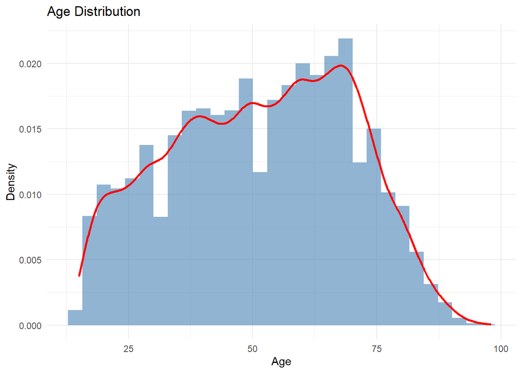

```r
ggplot(data_descriptive, aes(x = age)) +
  geom_histogram(aes(y = ..density..), bins = 30, fill = "steelblue", alpha = 0.6) +
  geom_density(color = "red", linewidth = 1) +
  theme_minimal() +
  labs(title = "Age Distribution", x = "Age", y = "Density")
```

Overall, the distribution supports the earlier summary statistics, where the median age was reported at 53 years, with the youngest quartile at 37 years or younger and the oldest quartile at 66 years or older. The relatively low representation of younger individuals could influence the overall attitudinal patterns observed in the study.

## Variable Distribution by Country

Next, we analyze the contextual differences between the countries surveyed in the dataset.

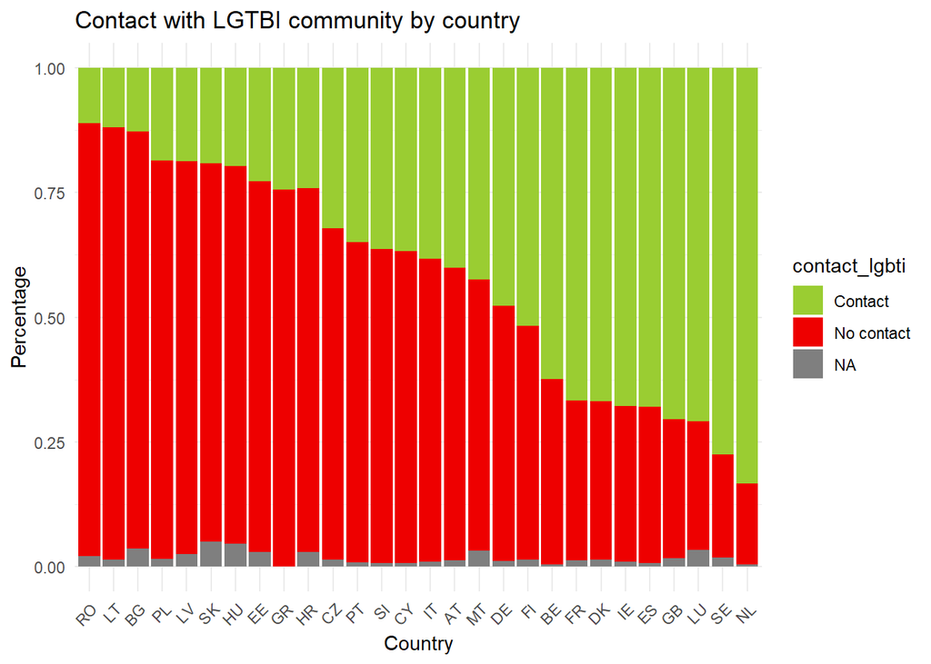

```r
#Contact with LGTBI community by country
country_order <- data_descriptive %>%
  filter(!is.na(contact_lgbti)) %>%
  group_by(isocntry) %>%
  summarise(no_contact_prop = mean(contact_lgbti == "No contact")) %>%
  arrange(desc(no_contact_prop))


ggplot(data_descriptive, aes(x = factor(isocntry, levels = country_order$isocntry), fill = contact_lgbti)) +
  geom_bar(position = "fill") +
  theme_minimal() +
  labs(title = "Contact with LGTBI community by country",
       x = "Country", y = "Percentage") +
  scale_fill_manual(values = c("Contact" = "olivedrab3", "No contact" = "red2")) +
  theme(axis.text.x = element_text(angle = 45, hjust = 1))
```

```r
data_country <- data_descriptive |>
  filter(!is.na(contact_lgbti)) |>
  group_by(isocntry) |>
  summarise(no_contact_prop = mean(contact_lgbti == "No contact")) |>
  mutate(contact_category = ifelse(no_contact_prop < 0.5, "Majority Contact", "Majority No Contact"))

map_data <- joinCountryData2Map(data_country, joinCode = "ISO2", nameJoinColumn = "isocntry")
```

```
## 28 codes from your data successfully matched countries in the map
## 0 codes from your data failed to match with a country code in the map
## 215 codes from the map weren't represented in your data
```

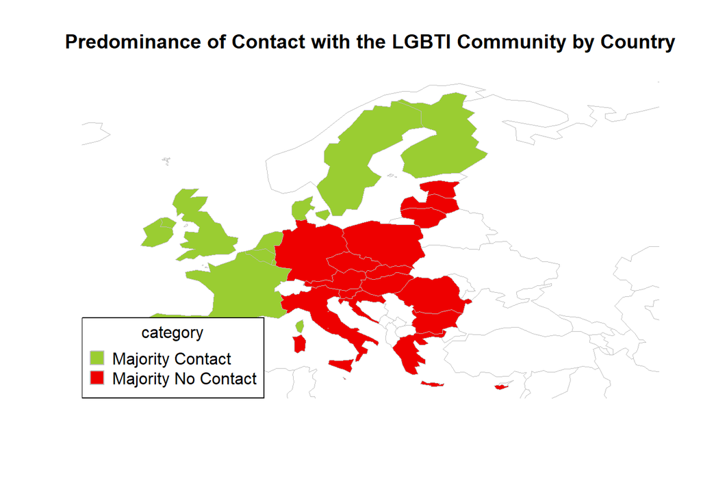

```r
color_palette <- c("Majority Contact" = "olivedrab3", "Majority No Contact" = "red2")

mapCountryData(map_data,
               nameColumnToPlot = "contact_category",
               mapTitle = "Predominance of Contact with the LGBTI Community by Country",
               catMethod = "categorical",
               colourPalette = color_palette,
               mapRegion = "Europe")
```

These two visualizations illustrate the distribution of contact with the LGBTI community across countries, highlighting significant regional differences in social exposure to LGBTI individuals.

The first bar chart presents the proportion of respondents in each country who report having contact with LGBTI individuals (green) versus those who do not (red), with a small portion of missing responses (gray). Countries are arranged from left to right based on decreasing levels of respondents lacking contact with the LGBTI community. Romania, Bulgaria, Poland, and several other Eastern European countries show the highest levels of non-contact, while the Netherlands, Sweden, and other Western and Northern European nations report the highest levels of contact. This suggests a strong regional divide in familiarity with LGBTI individuals.

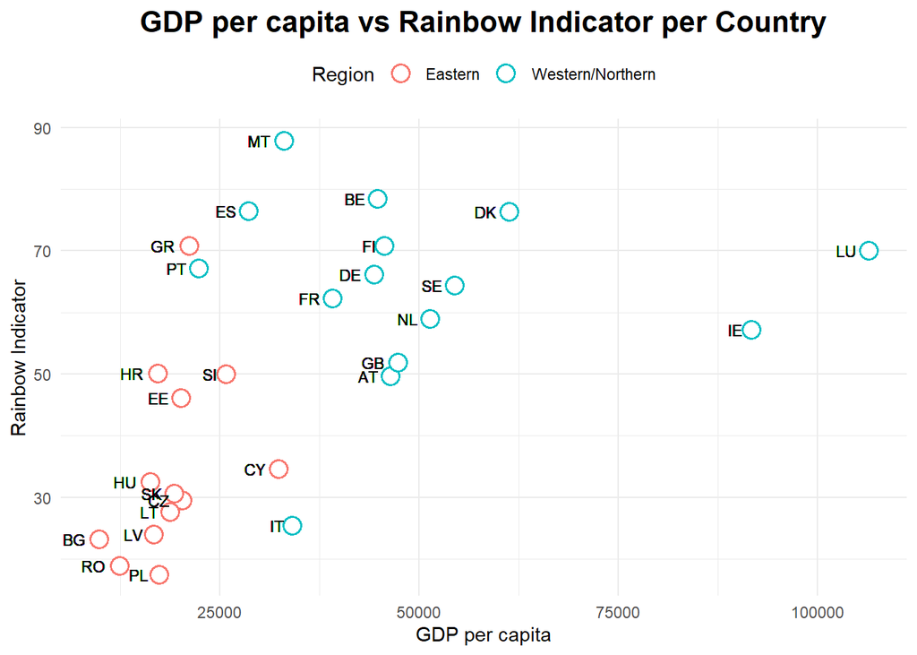

```r
western_northern <- c("AT", "BE", "DK", "FI", "FR", "DE", "IE", "IS", "LU", "NL", "NO", "SE", "CH", "ES", "PT", "IT", "GB", "MT")
eastern <- c("BG", "CZ", "EE", "HU", "LT", "LV", "PL", "RO", "RU", "SK", "SI", "HR", "UA", "GR", "CY")

data_descriptive$region <- case_when(
  data_descriptive$isocntry %in% western_northern ~ "Western/Northern",
  data_descriptive$isocntry %in% eastern ~ "Eastern",
  TRUE ~ "Other"
)

ggplot(data_descriptive, aes(x = gdp_pc, y = rain_ind, label = isocntry)) +
  geom_point(aes(color = region), size = 4, shape = 21, stroke = 1, fill = "white") +
  geom_text(size = 3, hjust = 1.6)  +
  theme_minimal() +
  labs(
    title = "GDP per capita vs Rainbow Indicator per Country",
    x = "GDP per capita",
    y = "Rainbow Indicator",
    color = "Region"
  ) +
  theme(
    plot.title = element_text(face = "bold", size = 16, hjust = 0.5),
    legend.position = "top")
```

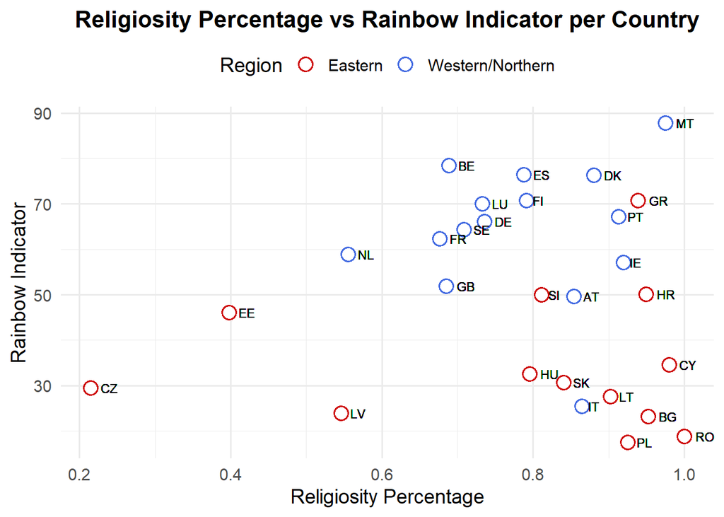

```r
ggplot(data_descriptive, aes(x = religiosity_percent, y = rain_ind, label = isocntry)) +
  geom_point(aes(color = case_when(
    isocntry %in% western_northern ~ "Western/Northern",
    isocntry %in% eastern ~ "Eastern",
    TRUE ~ "Other")), size = 4, shape = 21, stroke = 1, fill = "white") +
  geom_text(size = 3, hjust = -0.6) +
  scale_color_manual(values = c("Western/Northern" = "royalblue", "Eastern" = "red3", "Other" = "gray")) +
  theme_minimal(base_size = 14) +
  labs(
    title = "Religiosity Percentage vs Rainbow Indicator per Country",
    x = "Religiosity Percentage",
    y = "Rainbow Indicator",
    color = "Region"
  ) +
  theme(
    plot.title = element_text(face = "bold", size = 16, hjust = 0.5),
    legend.position = "top")
```

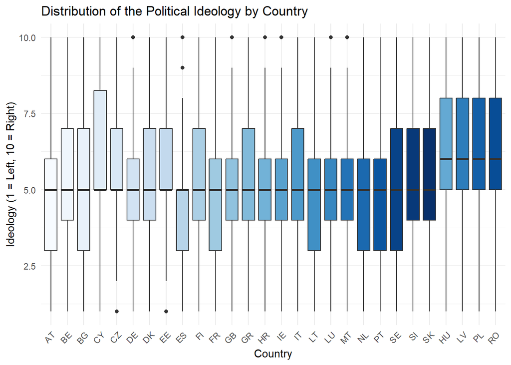

```r
#Distribution of the Political Ideology by Country

ggplot(data_descriptive, aes(x = reorder(isocntry, ideology, FUN = median, na.rm = TRUE), y = ideology, fill = isocntry)) +
  geom_boxplot() +
  theme_minimal() +
  labs(title = "Distribution of the Political Ideology by Country",
       x = "Country", y = "Ideology (1 = Left, 10 = Right)") +
  theme(axis.text.x = element_text(angle = 45, hjust = 1),
        legend.position = "none") +
   scale_fill_manual(values = colorRampPalette(brewer.pal(9, "Blues"))(28))
```

However, Spain is particularly interesting because, although its median ideology is similar to that of many other countries, the overall distribution is skewed to the left, meaning a larger proportion of respondents identify as left-wing compared to right-wing. This suggests that while the central tendency remains balanced, there is a stronger leftist presence in the country.

In contrast, some countries like the Czech Republic (CZ), Cyprus (CY), and Estonia (EE) exhibit the opposite trend. Their median scores remain relatively moderate, yet the distribution skews towards the right, implying a larger proportion of right-leaning individuals compared to left-leaning ones.

## Bivariate Analysis with Target Variable

```r
data_country <- aggregate(as.numeric(trans_doc) ~ isocntry, data = data_descriptive, mean, na.rm = TRUE)

map_data <- joinCountryData2Map(data_country, joinCode = "ISO2", nameJoinColumn = "isocntry")
```

```
## 28 codes from your data successfully matched countries in the map
## 0 codes from your data failed to match with a country code in the map
## 215 codes from the map weren't represented in your data
```

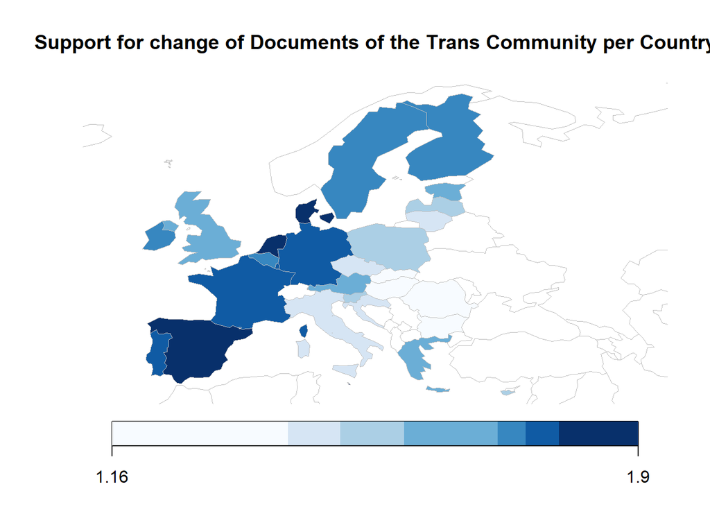

```r
mapCountryData(map_data,
               nameColumnToPlot = "as.numeric(trans_doc)",
               mapTitle = "Support for change of Documents of the Trans Community per Country",
               catMethod = "quantiles",
               colourPalette = brewer.pal(9, "Blues"),
               mapRegion = "Europe")
```

This choropleth map illustrates the level of support for transgender individuals’ right to change their official documents, our target variable, across different European countries. The color gradient, ranging from light blue (low support) to dark blue (high support), visually represents the variation in attitudes toward this issue.

In contrast, Central and Eastern European countries, including Poland, Hungary, and several Balkan states, show significantly lower levels of support, as reflected by the lighter shades. These countries tend to have more conservative social attitudes and restrictive legal frameworks regarding transgender rights. Italy stands out with surprisingly low support compared to other Western European nations. This suggests that despite being a major Western European country, Italy remains more conservative on transgender issues.

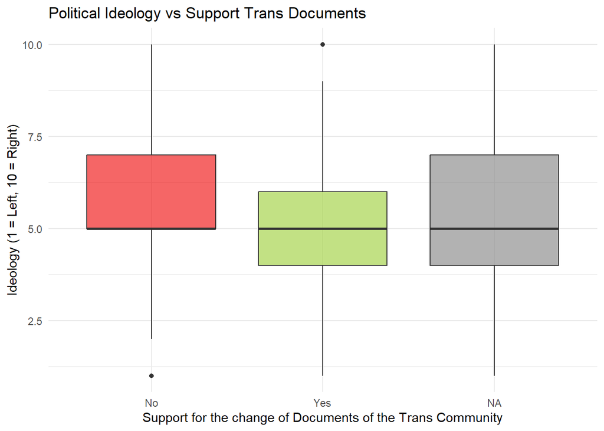

```r
ggplot(data_descriptive, aes(x = as.factor(trans_doc), y = ideology, fill = as.factor(trans_doc))) +
  geom_boxplot(alpha = 0.6) +
  theme_minimal() +
  labs(title = "Political Ideology vs Support Trans Documents",
       x = "Support for the change of Documents of the Trans Community",
       y = "Ideology (1 = Left, 10 = Right)") +
  scale_fill_manual(values = c("0" = "red2", "1" = "olivedrab3")) +
  scale_x_discrete(labels = c("0" = "No", "1" = "Yes")) +
  theme(legend.position = "none")
```

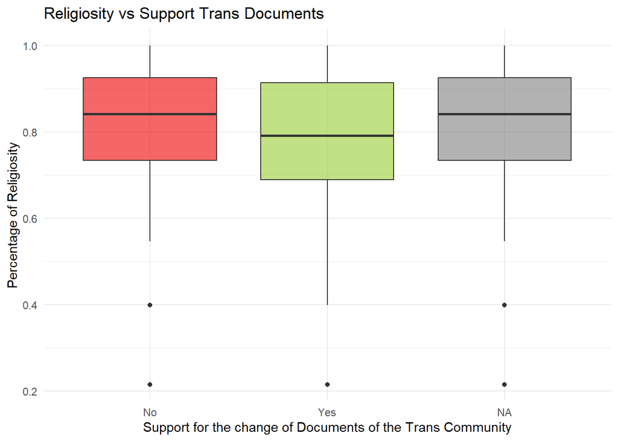

```r
ggplot(data_descriptive, aes(x = as.factor(trans_doc), y = religiosity_percent, fill = as.factor(trans_doc))) +
  geom_boxplot(alpha = 0.6) +
  theme_minimal() +
  labs(title = "Religiosity vs Support Trans Documents",
       x = "Support for the change of Documents of the Trans Community",
       y = "Percentage of Religiosity") +
  scale_fill_manual(values = c("0" = "red2", "1" = "olivedrab3")) +
  scale_x_discrete(labels = c("0" = "No", "1" = "Yes")) +
  theme(legend.position = "none")
```

These two boxplots examine the relationship between support for transgender individuals’ right to change their official documents and two factors: political ideology and religiosity.

In the first boxplot (Political Ideology vs. Support for Trans Documents), the median ideology score is similar across groups, meaning that those who support (green) and oppose (red) document changes have roughly the same central tendency. However, a key difference emerges in the distribution of responses: those who oppose the right to change documents have a longer right-leaning tail, indicating a higher presence of strongly right-wing individuals in this group. In contrast, supporters have a more centralized distribution, meaning they are not necessarily strongly left-wing, but rather clustered around moderate-left to centrist views. The NA category (gray) also has a similar median but a broader spread, covering both left- and right-leaning respondents more evenly.

The second boxplot (Religiosity vs. Support for Trans Documents) presents a slightly different pattern. Here, the median religiosity score is slightly higher for those who oppose document changes compared to supporters. However, unlike political ideology, the distribution of religiosity is more similar across groups, meaning that while opposition to trans rights is somewhat more frequent among more religious individuals, this is not highly significant

In summary, while there are some observable differences in political ideology and religiosity between those who support or oppose transgender rights, they are not highly significant. The distributions indicate that attitudes toward transgender document changes are influenced by multiple factors, with ideology and religiosity playing a role but not being the sole determinants.

## Other variables related to transgender persons

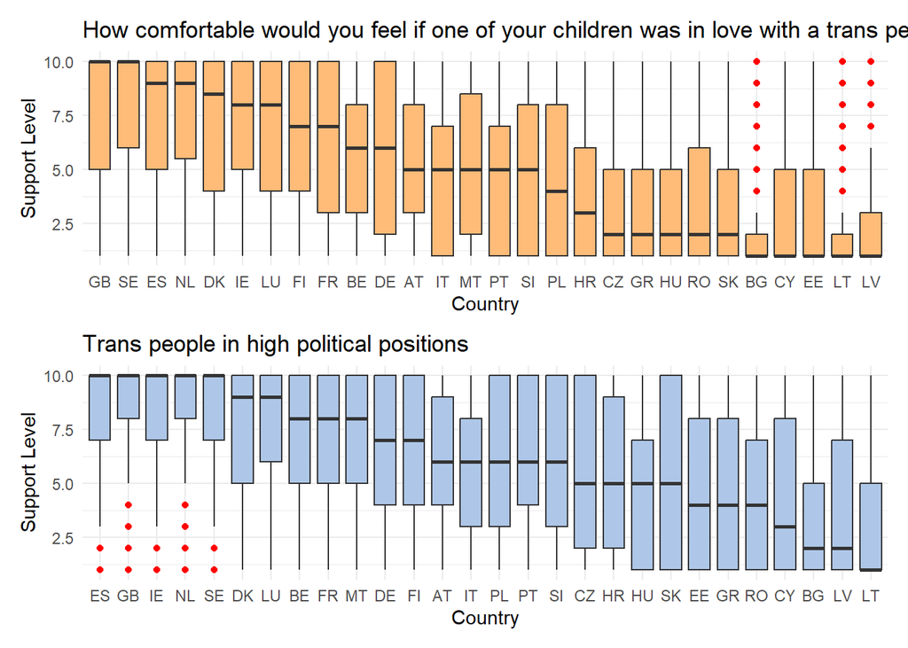

```r
# Boxplot 1: trans_child
b1 <- ggplot(other_variables,
             aes(x = reorder(isocntry, child_love, FUN = median, decreasing = TRUE),
                                  y = child_love)) +
  geom_boxplot(fill = "#FFBB78", outlier.colour = "red", outlier.fill = "red") +
  labs(title = "How comfortable would you feel if one of your children was in love with a trans person?",
       x = "Country", y = "Support Level") +
  theme(
    axis.text.x = element_text(angle = 0, hjust = 1),
    axis.title = element_text(size = 12, face = "bold")) +
  theme_minimal()


# Boxplot 2: trans_pol
b2 <- ggplot(other_variables,
             aes(x = reorder(isocntry, trans_pol, FUN = median, decreasing = TRUE),
                                  y = trans_pol)) +
  geom_boxplot(fill = "#AEC7E8", outlier.colour = "red", outlier.fill = "red") +
  labs(title = "Trans people in high political positions",
       x = "Country", y = "Support Level") +
  theme(
    axis.text.x = element_text(angle = 0, hjust = 1),
    axis.title = element_text(size = 12, face = "bold")) +
  theme_minimal()

# Boxplots combined
b <- b1 / b2
b
```

# Mice imputation

Before continuing to the models we take a look at missing values in the original Eurobarometer dataset and the possibility to impute them. We did the descriptive analysis without previous imputation as we perceived that descriptive makes only sense with the original dataset and the real values we know to be true.

First, we take a look at the NA distribution of the Eurobarometer dataset.

```r
colSums(is.na(individual_data))
```

```
##         caseid       serialid       isocntry      trans_doc         female
##              0              0              0           3280              0
##            age       religion marital_status personal_satis       ideology
##              0            483             68            102           4689
##  contact_lgbti   social_class     occupation
##            494           1021              0
```

```r
mice_data <- individual_data %>%
  drop_na(c(marital_status, personal_satis)) %>%
  select(-c(caseid))

serialid <- mice_data$serialid

mice_data <- mice_data %>%
  select(-c(serialid))

colSums(is.na(mice_data))
```

```
##       isocntry      trans_doc         female            age       religion
##              0           3214              0              0            448
## marital_status personal_satis       ideology  contact_lgbti   social_class
##              0              0           4599            472            973
##     occupation
##              0
```

We are left with 4599 NAs for ideology, 472 NAs for contact_lgbti, 448 NAs for religion and 973 NAs for social class.

First, we are going to manually look at the different imputation methods and strategies to understand how close they come to the original dataset. As there are factor and numerical variables, the best options to test tje imputation are Random Forest and Pmm methods.

```r
imputed_comparison <- data.frame(
  original = mice_data$ideology,
  imputed_rf = complete(mice(mice_data, method = "rf",
                             m = 3, maxit = 3,
                             seed = 123))$ideology,
  imputed_pmm = complete(mice(mice_data, method = "pmm",
                              m = 3, maxit = 3,
                              seed = 123))$ideology)
```

The m and the maxit arguments are = 3 to reduce loading time without losing so much information.

The next step is to plot the results to compare the resulting distributions:

[figure not shown]

```r
# Arguments for the plot
methods <- c("original", "imputed_rf" , "imputed_pmm")
titles <- c("Distribution of the Age Variable",
           "Random Forest-imputed Distribution",
            "PMM-imputed Distribution")
colors_fill <- c( "#E7CB94", "#E7969C", "#DE9ED6")


# Long format
data_imputed_long <- imputed_comparison |>
  pivot_longer(cols = all_of(methods), names_to = "method",
                values_to = "value") |>
  mutate(title = factor(method, levels = methods, labels = titles))


# Distributions comparison
plot_mice <- ggplot(data_imputed_long, aes(x = value, fill = title)) +
  geom_histogram(binwidth = 1, color = "black", position = "identity") +
  facet_wrap(~ title, scales = "free_y") +
  scale_fill_manual(values = colors_fill) +
  theme_classic() +
  theme(legend.position = "none")

plot_mice
```

```r
init = mice(mice_data, m = 3, seed = 123)
```

For our target variable trans_doc we set method=““, so that it is not imputed.

```r
meth = init$method

meth
```

```
##       isocntry      trans_doc         female            age       religion
##             ""       "logreg"             ""             ""      "polyreg"
## marital_status personal_satis       ideology  contact_lgbti   social_class
##             ""             ""          "pmm"       "logreg"      "polyreg"
##     occupation
##             ""
```

```r
meth[c("trans_doc")]=""

imputed_data = mice(mice_data, method=meth, m=3, seed=123)
summary(imputed_data)
```

```
## Class: mids
## Number of multiple imputations:  3
## Imputation methods:
##       isocntry      trans_doc         female            age       religion
##             ""             ""             ""             ""      "polyreg"
## marital_status personal_satis       ideology  contact_lgbti   social_class
##             ""             ""          "pmm"       "logreg"      "polyreg"
##     occupation
##             ""
## PredictorMatrix:
##                isocntry trans_doc female age religion marital_status
## isocntry              0         1      1   1        1              1
## trans_doc             1         0      1   1        1              1
## female                1         1      0   1        1              1
## age                   1         1      1   0        1              1
## religion              1         1      1   1        0              1
## marital_status        1         1      1   1        1              0
##                personal_satis ideology contact_lgbti social_class occupation
## isocntry                    1        1             1            1          1
## trans_doc                   1        1             1            1          1
## female                      1        1             1            1          1
## age                         1        1             1            1          1
## religion                    1        1             1            1          1
## marital_status              1        1             1            1          1
```

## Merging datasets again

For modeling, the best would be to use the function `with()` and all 3 generated datasets of mice, which would give us a better result but also take more time. Due to practicality and the point of the exercise not being focused on perfect mice usage, we take the decision of extracting and keep working with only one of the datasets.

```r
imputed_data_complete <- complete(imputed_data)

write.csv(imputed_data_complete, "imputed_data_complete.csv")
# my_data <- read.csv("imputed_data_complete.csv")
```

```r
data <- imputed_data_complete |>
  left_join(rainbow, by = c("isocntry" = "country_iso")) |>
  left_join(trans, by = c("isocntry" = "country_iso")) |>
  left_join(economic_indicators, by = c("isocntry" = "country_iso")) |>
  left_join(religiosity, by = c("isocntry" = "country_iso"))
```

# Explaining Cross-Country Differences

First of all, we performed a brief data preparation to enhance stability and model performance. First, we transformed GDP per capita with a natural logarithm to reduce the asymmetry of its distribution and make nonlinear relationships with other variables more manageable. Then, we reassigned the reference level of the categorical variable on contact with LGBTI people, setting “No contact” as the base category.

```r
data <- data |>
  mutate(gdp_pc = log(gdp_pc))

data$contact_lgbti <- relevel(data$contact_lgbti, ref = "No contact")

str(data)
```

```
## 'data.frame':    27271 obs. of  16 variables:
##  $ isocntry           : chr  "BE" "BE" "BE" "BE" ...
##  $ trans_doc          : Factor w/ 2 levels "0","1": 2 2 2 2 2 2 2 1 2 2 ...
##  $ female             : Factor w/ 2 levels "0","1": 1 2 2 1 2 2 1 1 2 2 ...
##  $ age                : num  51 62 38 29 63 41 48 88 44 45 ...
##  $ religion           : Factor w/ 5 levels "Christians","Muslims",..: 1 1 3 3 1 3 3 1 1 1 ...
##  $ marital_status     : Factor w/ 5 levels "Divorced","Married",..: 1 2 2 2 2 2 2 1 2 2 ...
##  $ personal_satis     : Factor w/ 2 levels "Not satisfied",..: 2 2 2 2 2 2 2 2 2 2 ...
##  $ ideology           : num  7 8 4 10 8 7 3 9 3 8 ...
##  $ contact_lgbti      : Factor w/ 2 levels "No contact","Contact": 1 1 2 2 1 1 1 1 2 2 ...
##  $ social_class       : Factor w/ 3 levels "High class","Middle class",..: 3 2 3 1 1 2 2 2 2 1 ...
##  $ occupation         : Factor w/ 5 levels "Employed","Retired",..: 1 5 1 1 5 1 1 2 5 1 ...
##  $ rain_ind           : num  78.5 78.5 78.5 78.5 78.5 ...
##  $ self_determination : chr  "1" "1" "1" "1" ...
##  $ gini               : num  26.6 26.6 26.6 26.6 26.6 26.6 26.6 26.6 26.6 26.6 ...
##  $ gdp_pc             : num  10.7 10.7 10.7 10.7 10.7 ...
##  $ religiosity_percent: num  0.689 0.689 0.689 0.689 0.689 ...
```

Then, we check for the multicollinearity in our model:

```r
model <- glm(trans_doc ~ scale(age) +
               female +
               religion +
               occupation +
               marital_status +
               personal_satis +
               contact_lgbti +
               scale(ideology) +
               social_class +
               scale(gdp_pc) +
               self_determination +
               scale(gini) +
               scale(rain_ind) +
               scale(religiosity_percent),
             family = "binomial", data = data)

summary(model)

exp(coef(model))

vif(model)
```

[output not shown]

We use the Variance Inflation Factor (VIF) to identify highly correlated predictor variables. In the results, the GVIF values indicate that the multicollinearity is not problematic, as most VIFs are below 2. This suggests there is no significant multicollinearity between the individual variables and collective variables, ensuring reliable coefficient estimates and proper interpretation of each variable’s effect.

Next, we test different models to identify key factors influencing support for transgender individuals’ right to decide on their own document.

```r
model2 <- glmer(trans_doc ~
                  scale(age) +
                  female +
                  religion +
                  occupation +
                  marital_status +
                  personal_satis +
                  contact_lgbti +
                  scale(ideology) +
                  social_class +
                  (1|isocntry),
                family = "binomial",
                data = data)
summary(model2)


model3 <- glmer(trans_doc ~
                  scale(age) +
                  I(scale(age)^2) +
                  female +
                  occupation +
                  religion*scale(religiosity_percent) +
                  marital_status*scale(religiosity_percent) +
                  personal_satis*self_determination +
                  contact_lgbti*scale(rain_ind) +
                  contact_lgbti*self_determination +
                  scale(ideology)*scale(gdp_pc) +
                  social_class*scale(gini) +
                  (1|isocntry),
                family = "binomial",
                data = data)
summary(model3)
```

We started with model2, a generalized linear mixed-effects model that includes a random intercept for each country to account for country-specific variation. Then, we tried model3, a more complex model that includes interaction terms (e.g., religion and religiosity, marital status and religiosity) to capture more nuanced relationships. Some variables like age, self-determination, and GDP per capita were not significant on their own, but interactions like religion and marital status showed relevance.

In model4, we extended the complexity further by adding additional interaction terms and quadratic terms, similar to model3. This model includes interactions like religion and religiosity percent, personal satisfaction and self-determination, and contact with LGBTI people with variables such as rain index and self-determination. We also included the interaction between ideology and GDP per capita and social class with the Gini index.

```r
model4 <- glmer(trans_doc ~
                  scale(age) +
                  I(scale(age)^2) +
                  female +
                  religion +
                  occupation +
                  religion:scale(religiosity_percent) +
                  marital_status +
                  personal_satis +
                  personal_satis:self_determination +
                  contact_lgbti*scale(rain_ind) +
                  contact_lgbti:self_determination +
                  scale(ideology) +
                  scale(ideology):scale(gdp_pc) +
                  social_class*scale(gini) +
                  (1|isocntry),
                family = "binomial",
                data = data)
summary(model4)
```

However, after reviewing the results, we found that certain variables, such as self-determination, personal satisfaction, Gini, and social class, were not significant.

In model5, we included additional variables and interactions, while also refining the previous interactions. This model examines the impact of variables like age, gender, religion, occupation, and their interactions, such as religion with religiosity percentage, contact with LGBTI people with rain index, and ideology with GDP per capita.

```r
model5 <- glmer(trans_doc ~
                  scale(age) +
                  I(scale(age) ^ 2) +
                  female +
                  occupation +
                  religion +
                  religion:scale(religiosity_percent) +
                  marital_status +
                  personal_satis +
                  contact_lgbti*scale(rain_ind) +
                  contact_lgbti:self_determination +
                  ideology +
                  ideology:scale(gdp_pc) +
                  social_class +
                  scale(gini) +
                  (1|isocntry),
                family = "binomial",
                data = data)
summary(model5)
```

In model6, we further refined the model by removing non-significant variables from previous iterations, resulting in a more streamlined approach

```r
model6 <- glmer(trans_doc ~
                  scale(age) +
                  I(scale(age) ^ 2) +
                  female +
                  occupation +
                  religion +
                  religion:scale(religiosity_percent) +
                  marital_status +
                  personal_satis +
                  contact_lgbti*scale(rain_ind) +
                  ideology +
                  ideology:scale(gdp_pc) +
                  (1|isocntry),
                family = "binomial",
                data = data)
summary(model6)
```

After evaluating the results, we found that marital status was not significant in predicting support for transgender rights.

In model7, we further simplified the model by removing marital status based on the previous findings.

```r
model7 <- glmer(trans_doc ~
                  scale(age) +
                  I(scale(age) ^ 2) +
                  female +
                  occupation +
                  religion +
                  religion:scale(religiosity_percent) +
                  personal_satis +
                  contact_lgbti*scale(rain_ind) +
                  ideology +
                  ideology:scale(gdp_pc) +
                  (1|isocntry),
                family = "binomial",
                data = data)
summary(model7)
```

In model8, we introduced random slopes alongside random intercepts. Specifically, we modeled age, gender (female), and ideology as having random slopes by country. The random intercepts allow for country-specific baselines, and the random slopes allow us to capture how the relationships between these predictors and the target variable may differ between countries.

```r
model8 <- glmer(trans_doc ~
                  scale(age) +
                  I(age ^ 2) +
                  female +
                  occupation +
                  religion +
                  religion:scale(religiosity_percent) +
                  personal_satis +
                  contact_lgbti*scale(rain_ind) +
                  ideology +
                  ideology:scale(gdp_pc) +
                  (1 + scale(age) + female + scale(ideology)|isocntry),
                family = "binomial",
                data = data)
summary(model8)

ranef(model8) |>  # This is for extracting random intercepts and slopes
  str()
```

[output not shown]

The random effects output shows how intercepts and slopes vary by country. The (Intercept) column represents country-specific deviations from the overall intercept. The scale(age), female1, and scale(ideology) columns indicate how these predictors’ effects differ across countries. The values suggest small but varying influences of age, gender, and ideology on the target variable, depending on the country.

In step_model, we continued refining the model by incorporating both age and its squared term (age^2). The rationale behind this is that the linear term (age) and the quadratic term (age^2) work together to model a curvilinear relationship. Even though age itself may not be significant, we retain it in the model because the combined effect of both terms allows for capturing a potential non-linear relationship with the target variable. This helps to better model the relationship between age and support for transgender rights.

The model includes additional predictors like female, occupation, and religion interactions with religiosity_percent, along with other interaction terms such as contact_lgbti with rain index and ideology with GDP per capita. We also kept the random slopes for age, female, and ideology across countries, as these allow the effects of these variables to vary by country.

```r
step_model <- glmer(trans_doc ~
                  scale(age) +
                  I(scale(age)^2) +
                  female +
                  occupation +
                  religion*scale(religiosity_percent) +
                  marital_status*scale(religiosity_percent) +
                  personal_satis*self_determination +
                  contact_lgbti*scale(rain_ind) +
                  contact_lgbti*self_determination +
                  scale(ideology)*scale(gdp_pc) +
                  social_class*scale(gini) +
                  (1 + scale(age) +
                     female +
                     scale(ideology)
                     |isocntry),
                family = "binomial",
                data = data)

summary(step_model)
```

[output not shown]

The results showed that age (quadratic), gender, occupation, personal satisfaction, contact with LGBTI people, and ideology were relevant predictors. Additionally, interactions between religion and religiosity, as well as ideology and GDP, played a significant role. However, variables like marital status, social class, and the Gini index were not significant, leading to their exclusion in the final model:

```r
final_model <- glmer(trans_doc ~
                      scale(age) +
                      I(scale(age)^2) +
                      female +
                      occupation +
                      religion*scale(religiosity_percent) +
                      personal_satis +
                      contact_lgbti*scale(rain_ind) +
                      self_determination +
                      scale(ideology)*scale(gdp_pc) +
                      (1 + scale(age) +
                         female +
                         scale(ideology)
                       |isocntry),
                    family = "binomial",
                    data = data)

summary(final_model)
```

```
## Generalized linear mixed model fit by maximum likelihood (Laplace
##   Approximation) [glmerMod]
##  Family: binomial  ( logit )
## Formula: trans_doc ~ scale(age) + I(scale(age)^2) + female + occupation +
##     religion * scale(religiosity_percent) + personal_satis +
##     contact_lgbti * scale(rain_ind) + self_determination + scale(ideology) *
##     scale(gdp_pc) + (1 + scale(age) + female + scale(ideology) |      isocntry)
##    Data: data
##
##      AIC      BIC   logLik deviance df.resid
##  26218.7  26501.7 -13074.3  26148.7    24022
##
## Scaled residuals:
##     Min      1Q  Median      3Q     Max
## -7.2358 -0.7544  0.3495  0.6583  4.5852
##
## Random effects:
##  Groups   Name            Variance Std.Dev. Corr
##  isocntry (Intercept)     0.24039  0.4903
##           scale(age)      0.03823  0.1955   -0.10
##           female1         0.02723  0.1650    0.41  0.22
##           scale(ideology) 0.01368  0.1170   -0.78  0.10 -0.01
## Number of obs: 24057, groups:  isocntry, 28
##
## Fixed effects:
##                                                       Estimate Std. Error
## (Intercept)                                           -0.55986    0.12871
## scale(age)                                            -0.04401    0.04513
## I(scale(age)^2)                                       -0.07489    0.01902
## female1                                                0.37739    0.04486
## occupationRetired                                     -0.16424    0.05283
## occupationSelf employed                                0.13747    0.06104
## occupationStudent                                      0.22628    0.08352
## occupationUnemployed                                   0.05261    0.05580
## religionMuslims                                       -0.46336    0.13378
## religionNot religious                                  0.36087    0.04747
## religionOrthodox Chrsitian                            -0.02305    0.07488
## religionOther religions                               -0.12507    0.07797
## scale(religiosity_percent)                            -0.19005    0.09715
## personal_satisSatisfied                                0.37616    0.04366
```

[output cut: 24 more lines]

```
## scale(religiosity_percent)                             -1.956 0.050439 .
## personal_satisSatisfied                                 8.615  < 2e-16 ***
## contact_lgbtiContact                                   25.570  < 2e-16 ***
## scale(rain_ind)                                         1.695 0.090139 .
## self_determination1                                     1.852 0.063993 .
## scale(ideology)                                        -6.821 9.02e-12 ***
## scale(gdp_pc)                                           1.707 0.087816 .
## religionMuslims:scale(religiosity_percent)             -0.213 0.831500
## religionNot religious:scale(religiosity_percent)        1.715 0.086267 .
## religionOrthodox Chrsitian:scale(religiosity_percent)   3.193 0.001407 **
## religionOther religions:scale(religiosity_percent)     -3.462 0.000536 ***
## contact_lgbtiContact:scale(rain_ind)                    1.258 0.208564
## scale(ideology):scale(gdp_pc)                          -3.767 0.000165 ***
## ---
## Signif. codes:  0 '***' 0.001 '**' 0.01 '*' 0.05 '.' 0.1 ' ' 1
```

```
##
## Correlation matrix not shown by default, as p = 25 > 12.
## Use print(x, correlation=TRUE)  or
##     vcov(x)        if you need it
```

```r
lme4::ranef(final_model) %>%
  str
```

```
## List of 1
##  $ isocntry:'data.frame':    28 obs. of  4 variables:
##   ..$ (Intercept)    : num [1:28] 0.0232 -0.5232 -0.7716 0.1831 -0.71 ...
##   ..$ scale(age)     : num [1:28] -0.126 0.544 -0.251 0.131 0.2 ...
##   ..$ female1        : num [1:28] 0.00421 0.0964 -0.1408 -0.03527 -0.04934 ...
##   ..$ scale(ideology): num [1:28] -0.00302 0.11199 0.13851 -0.01833 0.19367 ...
##   ..- attr(*, "postVar")= num [1:4, 1:4, 1:28] 0.006147 0.000703 -0.003287 -0.001168 0.000703 ...
##  - attr(*, "class")= chr "ranef.mer"
```

In final_model, we have refined the model to include both age and its squared term (age^2), maintaining them together to model a curvilinear relationship between age and the target variable.

Regarding the results, support for trans rights is influenced by several factors. Being a woman significantly increases support, while age has a curvilinear effect, with a decline at older ages. Being retired reduces support, and religiosity also plays a role, particularly in some religious groups where lower acceptance is observed. In contrast, being non-religious is associated with a more favorable stance. Personal satisfaction and contact with LGBTI individuals have strong positive and highly significant effects, suggesting that social interaction strongly shapes attitudes. Additionally, while a more conservative ideology decreases support, this effect is moderated by the country’s GDP per capita.

In terms of random effects, there is variation between countries in the intercept and in the slopes of age, gender, and ideology, indicating that these factors do not influence attitudes in the same way across national contexts. Overall, the model confirms that support for trans rights is a multifaceted phenomenon shaped by both individual and structural factors.

# Predictive models

For the predictive part of the model we are going to try the predictive capability of our explanatory model and after that we will try some machine learning techniques as K-nearest neighbours, decision trees and random forest.

We will have two type of training and testing sets. The first one is going to be used in the prediction with the explanatory model and the knn and it will consist in a training set that will contain 70% of the data of each country and in a testing set that will have 30% of the data of each country. The reason behind this splitting is that in the explanatory model we will have random intercept and slopes for each country and in the knn is because it does not admit new levels.

The second set will follow the same 70/30 structure but with a crucial difference—it will leave out one country entirely. This approach allows us to evaluate whether the models can generalize effectively to completely unseen datasets, providing a more robust test of their predictive performance.

```r
set.seed(123)

# reinsert serialid to be able to pinpoint observations
data$serialid <- serialid

# training and testing set
training <- data %>%
  group_by(isocntry) %>%
  sample_frac(0.7) %>%
  ungroup()

testing <- data %>%
  anti_join(training, by = c("serialid"))

# remove serialid from the model dataset
training <- training %>%
  select(-serialid)

testing <- testing  %>%
  select(-serialid)

# training model
final_model <- glmer(trans_doc ~
                       scale(age) +
                       I(scale(age)^2) +
                       female +
                       occupation +
                       religion*scale(religiosity_percent) +
                       personal_satis +
                       contact_lgbti*scale(rain_ind) +
                       self_determination +
                       scale(ideology)*scale(gdp_pc) +
                       (1  + scale(age) +
                          female +
                          scale(ideology)
                        |isocntry),
                     family = binomial(link = "logit"),
                     control = glmerControl(optimizer = "bobyqa", optCtrl = list(maxfun = 100000)),
                     data = training)
```

```
## boundary (singular) fit: see help('isSingular')
```

```r
summary(final_model)
```

```
## Generalized linear mixed model fit by maximum likelihood (Laplace
##   Approximation) [glmerMod]
##  Family: binomial  ( logit )
## Formula: trans_doc ~ scale(age) + I(scale(age)^2) + female + occupation +
##     religion * scale(religiosity_percent) + personal_satis +
##     contact_lgbti * scale(rain_ind) + self_determination + scale(ideology) *
##     scale(gdp_pc) + (1 + scale(age) + female + scale(ideology) |      isocntry)
##    Data: training
## Control: glmerControl(optimizer = "bobyqa", optCtrl = list(maxfun = 1e+05))
##
##      AIC      BIC   logLik deviance df.resid
##  18253.4  18524.0  -9091.7  18183.4    16797
##
## Scaled residuals:
##     Min      1Q  Median      3Q     Max
## -7.7042 -0.7378  0.3432  0.6528  4.5985
##
## Random effects:
##  Groups   Name            Variance Std.Dev. Corr
##  isocntry (Intercept)     0.22289  0.4721
##           scale(age)      0.03868  0.1967   -0.31
##           female1         0.04215  0.2053    0.63 -0.01
##           scale(ideology) 0.01806  0.1344   -0.82  0.26 -0.08
## Number of obs: 16832, groups:  isocntry, 28
##
## Fixed effects:
##                                                       Estimate Std. Error
## (Intercept)                                           -0.52059    0.12783
## scale(age)                                            -0.02680    0.04845
## I(scale(age)^2)                                       -0.06600    0.02281
## female1                                                0.39057    0.05474
## occupationRetired                                     -0.22608    0.06320
## occupationSelf employed                                0.14972    0.07341
## occupationStudent                                      0.29905    0.10135
## occupationUnemployed                                   0.03344    0.06728
## religionMuslims                                       -0.43851    0.16409
## religionNot religious                                  0.38864    0.05693
## religionOrthodox Chrsitian                            -0.05507    0.08797
## religionOther religions                               -0.09001    0.09448
## scale(religiosity_percent)                            -0.19284    0.09160
```

[output cut: 25 more lines]

```
## scale(religiosity_percent)                             -2.105 0.035265 *
## personal_satisSatisfied                                 6.763 1.35e-11 ***
## contact_lgbtiContact                                   21.098  < 2e-16 ***
## scale(rain_ind)                                         1.757 0.078860 .
## self_determination1                                     1.938 0.052603 .
## scale(ideology)                                        -6.270 3.61e-10 ***
## scale(gdp_pc)                                           2.340 0.019303 *
## religionMuslims:scale(religiosity_percent)             -1.173 0.240963
## religionNot religious:scale(religiosity_percent)        1.506 0.132050
## religionOrthodox Chrsitian:scale(religiosity_percent)   2.774 0.005530 **
## religionOther religions:scale(religiosity_percent)     -2.927 0.003427 **
## contact_lgbtiContact:scale(rain_ind)                    1.551 0.120837
## scale(ideology):scale(gdp_pc)                          -3.547 0.000390 ***
## ---
## Signif. codes:  0 '***' 0.001 '**' 0.01 '*' 0.05 '.' 0.1 ' ' 1
```

```
##
## Correlation matrix not shown by default, as p = 25 > 12.
## Use print(x, correlation=TRUE)  or
##     vcov(x)        if you need it
```

```
## optimizer (bobyqa) convergence code: 0 (OK)
## boundary (singular) fit: see help('isSingular')
```

```r
# complete cases
training <- training[complete.cases(training), ]
testing <- testing[complete.cases(testing), ]

# prediction
pred <- predict(final_model, newdata = testing, type = "response")

# pred() worked:
prediction <- as.factor(ifelse(pred > 0.5, 1, 0))

# final:
confusionMatrix(prediction, testing$trans_doc)
```

```
## Confusion Matrix and Statistics
##
##           Reference
## Prediction    0    1
##          0 1711  840
##          1 1235 3439
##
##                Accuracy : 0.7128
##                  95% CI : (0.7022, 0.7232)
##     No Information Rate : 0.5922
##     P-Value [Acc > NIR] : < 2.2e-16
##
##                   Kappa : 0.3927
##
##  Mcnemar's Test P-Value : < 2.2e-16
##
##             Sensitivity : 0.5808
##             Specificity : 0.8037
##          Pos Pred Value : 0.6707
##          Neg Pred Value : 0.7358
##              Prevalence : 0.4078
##          Detection Rate : 0.2368
##    Detection Prevalence : 0.3531
##       Balanced Accuracy : 0.6922
##
##        'Positive' Class : 0
##
```

```r
confusionMatrix(prediction, testing$trans_doc)$overall[1:2]
```

```
##  Accuracy     Kappa
## 0.7128028 0.3926809
```

We obtain a pretty good accuracy

# K-NN

```r
ctrl <- trainControl(method = "repeatedcv",
                     number = 5,
                     classProbs = T,
                     summaryFunction=twoClassSummary,
                     verboseIter = T)

training <- as.data.frame(training)

training$isocntry <- factor(training$isocntry)
testing$isocntry <- factor(testing$isocntry)

training <- training |>
  mutate(trans_doc = case_when(
    trans_doc == "1" ~ "Yes",
    trans_doc == "0" ~ "No",
    TRUE ~ NA),
    trans_doc = factor(trans_doc))

testing <- testing |>
  mutate(trans_doc = case_when(
    trans_doc == "1" ~ "Yes",
    trans_doc == "0" ~ "No",
    TRUE ~ NA),
    trans_doc = factor(trans_doc))

str(training)
```

```
## 'data.frame':    16832 obs. of  16 variables:
##  $ isocntry           : Factor w/ 28 levels "AT","BE","BG",..: 1 1 1 1 1 1 1 1 1 1 ...
##  $ trans_doc          : Factor w/ 2 levels "No","Yes": 2 2 2 2 2 2 1 1 1 1 ...
##  $ female             : Factor w/ 2 levels "0","1": 2 2 1 1 2 1 2 1 2 1 ...
##  $ age                : num  53 34 48 31 38 45 31 68 58 55 ...
##  $ religion           : Factor w/ 5 levels "Christians","Muslims",..: 1 1 1 3 1 1 3 1 1 1 ...
##  $ marital_status     : Factor w/ 5 levels "Divorced","Married",..: 2 4 2 4 2 4 2 2 2 2 ...
##  $ personal_satis     : Factor w/ 2 levels "Not satisfied",..: 2 1 2 1 2 2 1 2 2 2 ...
##  $ ideology           : num  7 3 6 9 2 5 8 7 7 5 ...
##  $ contact_lgbti      : Factor w/ 2 levels "No contact","Contact": 2 1 2 1 1 2 1 1 1 1 ...
##  $ social_class       : Factor w/ 3 levels "High class","Middle class",..: 2 2 2 3 2 2 2 2 2 3 ...
##  $ occupation         : Factor w/ 5 levels "Employed","Retired",..: 5 1 3 5 1 1 1 2 3 1 ...
##  $ rain_ind           : num  49.6 49.6 49.6 49.6 49.6 ...
##  $ self_determination : chr  "0" "0" "0" "0" ...
##  $ gini               : num  30.7 30.7 30.7 30.7 30.7 30.7 30.7 30.7 30.7 30.7 ...
##  $ gdp_pc             : num  10.7 10.7 10.7 10.7 10.7 ...
##  $ religiosity_percent: num  0.854 0.854 0.854 0.854 0.854 ...
```

```r
knnFit <- train(trans_doc ~ .,
                data = training,
                method = "kknn",
                preProc=c('scale','center'),
                tuneLength = 10,
                metric="ROC",
                trControl = ctrl)
knnProb <- predict(knnFit, testing, type="prob", )
prediction <- as.factor(ifelse(knnProb[,2] > 0.5, "Yes", "No"))


confusionMatrix(prediction, testing$trans_doc)$table
```

```
##           Reference
## Prediction   No  Yes
##        No  1653  868
##        Yes 1293 3411
```

```r
confusionMatrix(prediction, testing$trans_doc)$overall[1:2]
```

```
##  Accuracy     Kappa
## 0.7008997 0.3664838
```

This model has a little worst accuracy than the our explanatory model.

## Decision trees

From now on, we will do not have Finland in the training set.

```r
# Separate Finland as our test country
data$serialid <- serialid

no_fi <- data |>
  filter(isocntry != "FI") |>
  mutate(trans_doc = case_when(
    trans_doc == "1" ~ "Yes",
    trans_doc == "0" ~ "No",
    TRUE ~ NA
  ))

test_country_fi <- data |>
  filter(isocntry == "FI")|>
  mutate(trans_doc = case_when(
    trans_doc == "1" ~ "Yes",
    trans_doc == "0" ~ "No",
    TRUE ~ NA
  ))

# training and testing set
training2 <- no_fi %>%
  group_by(isocntry) %>%
  sample_frac(0.7) %>%
  ungroup()

test_no_fi <- no_fi %>%
  anti_join(training2, by = c("serialid"))

testing2 <- test_no_fi |>
  bind_rows(test_country_fi)

# remove serialid from the model dataset
training2 <- training2 %>%
  select(-c(serialid, isocntry))

testing2 <- testing2  %>%
  select(-c(serialid, isocntry))

test_country_fi <- test_country_fi |>
  select(-c(serialid, isocntry))
```

```r
training2 <- training2[complete.cases(training2), ]
testing2 <- testing2[complete.cases(testing2), ]
test_no_fi <- test_no_fi[complete.cases(test_no_fi), ]
test_country_fi <- test_country_fi[complete.cases(test_country_fi), ]
```

```r
training2$trans_doc <- as.factor(training2$trans_doc)

training2 <- as.data.frame(training2)

control <- rpart.control(minsplit = 30, maxdepth = 10, cp=0.01)

model <- trans_doc ~ .
dtFit <- rpart(model, data=training2, method = "class", control = control)
summary(dtFit)
```

```
## Call:
## rpart(formula = model, data = training2, method = "class", control = control)
##   n= 16203
##
##           CP nsplit rel error    xerror        xstd
## 1 0.18862138      0 1.0000000 1.0000000 0.009572552
## 2 0.04784542      1 0.8113786 0.8113786 0.009153963
## 3 0.01000000      3 0.7156878 0.7156878 0.008839641
##
## Variable importance
##            rain_ind              gdp_pc religiosity_percent       contact_lgbti
##                  27                  25                  14                  13
##  self_determination                gini            religion
##                  12                   7                   1
##
## Node number 1: 16203 observations,    complexity param=0.1886214
##   predicted class=Yes  expected loss=0.4024563  P(node) =1
##     class counts:  6521  9682
##    probabilities: 0.402 0.598
##   left son=2 (8164 obs) right son=3 (8039 obs)
##   Primary splits:
##       rain_ind            < 50.975   to the left,  improve=983.5302, (0 missing)
##       contact_lgbti       splits as  LR,           improve=873.5439, (0 missing)
##       gdp_pc              < 9.93729  to the left,  improve=872.3062, (0 missing)
##       self_determination  splits as  LR,           improve=401.0324, (0 missing)
##       religiosity_percent < 0.79145  to the right, improve=380.2319, (0 missing)
##   Surrogate splits:
##       gdp_pc              < 9.93729  to the left,  agree=0.864, adj=0.726, (0 split)
##       self_determination  splits as  LR,           agree=0.744, adj=0.485, (0 split)
##       religiosity_percent < 0.79145  to the right, agree=0.713, adj=0.422, (0 split)
##       contact_lgbti       splits as  LR,           agree=0.683, adj=0.361, (0 split)
##       gini                < 34.7     to the right, agree=0.602, adj=0.198, (0 split)
##
## Node number 2: 8164 observations,    complexity param=0.04784542
##   predicted class=No   expected loss=0.4246693  P(node) =0.5038573
##     class counts:  4697  3467
##    probabilities: 0.575 0.425
##   left son=4 (1771 obs) right son=5 (6393 obs)
##   Primary splits:
##       gdp_pc              < 9.710632 to the left,  improve=256.93210, (0 missing)
```

[output cut: 28 more lines]

```
##       rain_ind      < 32.625   to the left,  improve= 34.62362, (0 missing)
##       occupation    splits as  RLRRR,        improve= 33.37894, (0 missing)
##       gdp_pc        < 9.887161 to the left,  improve= 33.29937, (0 missing)
##   Surrogate splits:
##       occupation splits as  LLLRL, agree=0.714, adj=0.014, (0 split)
##
## Node number 10: 4539 observations
##   predicted class=No   expected loss=0.4181538  P(node) =0.2801333
##     class counts:  2641  1898
##    probabilities: 0.582 0.418
##
## Node number 11: 1854 observations
##   predicted class=Yes  expected loss=0.3317152  P(node) =0.1144233
##     class counts:   615  1239
##    probabilities: 0.332 0.668
```

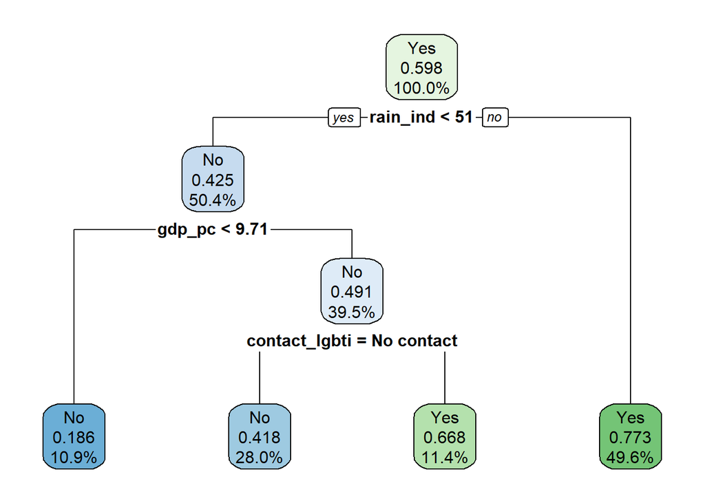

```r
rpart.plot(dtFit, digits=3)
```

```r
dtPred <- predict(dtFit, testing2, type = "class")

dtProb <- predict(dtFit, testing2, type = "prob")

prediction <- as.factor(ifelse(dtProb[,2] > 0.5, "Yes", "No"))

testing2$trans_doc <- factor(testing2$trans_doc)

confusionMatrix(prediction, testing2$trans_doc)$table
```

```
##           Reference
## Prediction   No  Yes
##        No  1798  943
##        Yes 1313 3800
```

```r
confusionMatrix(prediction, testing2$trans_doc)$overall[1:2]
```

```
##  Accuracy     Kappa
## 0.7127578 0.3870495
```

```r
caret.fit <- train(model,
                   data = training2,
                   method = "rpart",
                   control=rpart.control(minsplit = 8, maxdepth = 12),
                   trControl = ctrl,
                   tuneLength=10)
caret.fit
```

```
## CART
##
## 16203 samples
##    14 predictor
##     2 classes: 'No', 'Yes'
##
## No pre-processing
## Resampling: Cross-Validated (5 fold, repeated 1 times)
## Summary of sample sizes: 12963, 12962, 12963, 12962, 12962
## Resampling results across tuning parameters:
##
##   cp            ROC        Sens       Spec
##   0.0006900782  0.7630739  0.6048188  0.7926055
##   0.0007667536  0.7618356  0.5925504  0.8012800
##   0.0008178705  0.7617616  0.5923971  0.8021064
##   0.0009201043  0.7608190  0.5922416  0.8006618
##   0.0013801564  0.7592361  0.5899438  0.8003511
##   0.0019424424  0.7593294  0.6025199  0.7937430
##   0.0024536114  0.7572079  0.6249126  0.7777333
##   0.0035781833  0.7434340  0.6399357  0.7636847
##   0.0478454225  0.6981598  0.6801229  0.6929325
##   0.1886213771  0.5698110  0.2839402  0.8556818
##
## ROC was used to select the optimal model using the largest value.
## The final value used for the model was cp = 0.0006900782.
```

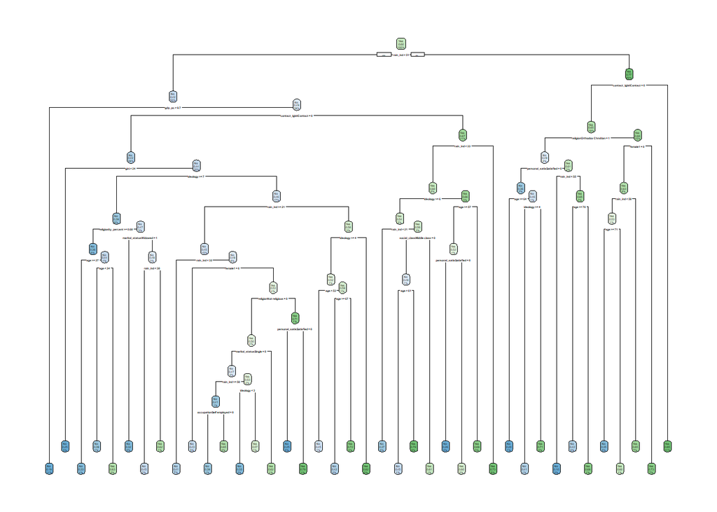

```r
rpart.plot(caret.fit$finalModel)
```

```r
dtProb <- predict(caret.fit, testing2, type = "prob")

prediction <- as.factor(ifelse(dtProb[,2] > 0.5, "Yes", "No"))

confusionMatrix(prediction, testing2$trans_doc)$table
```

```
##           Reference
## Prediction   No  Yes
##        No  1794  911
##        Yes 1317 3832
```

```r
confusionMatrix(prediction, testing2$trans_doc)$overall[1:2]
```

```
##  Accuracy     Kappa
## 0.7163229 0.3934242
```

## Random Forest

```r
rfFit <- train(trans_doc ~ .,
               data = training2,
               method = "rf",
               preProc=c('scale','center'),
               tuneLength = 10,
               metric="ROC",
               trControl = ctrl)
```

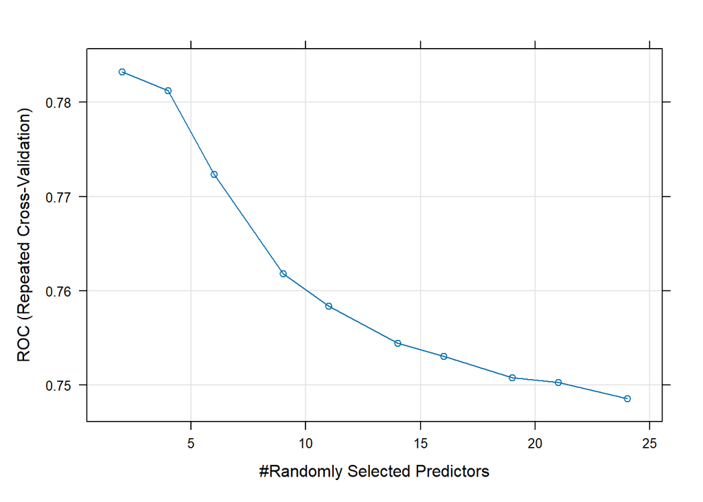

```r
plot(rfFit)
```

```r
rfProb <- predict(rfFit, testing2, type="prob")
prediction <- as.factor(ifelse(rfProb[,2] > 0.5, "Yes", "No"))

confusionMatrix(prediction, testing2$trans_doc)$table
```

```
##           Reference
## Prediction   No  Yes
##        No  1767  872
##        Yes 1344 3871
```

```r
confusionMatrix(prediction, testing2$trans_doc)$overall[1:2]
```

```
##  Accuracy     Kappa
## 0.7178508 0.3944302
```